# Lanying Wang individual

Lanying Wang

2023-09-05

The United States Census Bureau, Associate Director forDemographic Programs on behalf of the United States Department of Health and Human Services (HHS), Health Resources and Services Administration’s (HRSA) Maternal and Child Health Bureau(MCHB) conducted the 2021 NSCH. The NSCH is a household survey that produces national and state-level data on the physical and emotional health of children 0 - 17 years old in the United States. The survey collects information related to the health and well-being of children, including access to and use of health care, family interactions, parental health, school and after-school experiences, and neighborhood characteristics. These two datasets is created in 2021, and compared to earlier datasets more variables were measured.The former one is the screener dataset, while the later one is the topical dataset

```r
colnames(screener_data)
```

```
##  [1] "FIPSST"          "STRATUM"         "TOTKIDS_R"       "TENURE"
##  [5] "HHLANGUAGE"      "YEAR"            "CBSAFP_YN"       "METRO_YN"
##  [9] "MPC_YN"          "TENURE_IF"       "HHIDS"           "FWH"
## [13] "LINENUM"         "C_AGE_YEARS"     "C_RACE_R"        "C_RACE_R_IF"
## [17] "C_HISPANIC_R_IF" "C_SEX_IF"        "RACER"           "RACEASIA"
## [21] "RACEAIAN"        "C_HISPANIC_R"    "C_SEX"           "C_ENGLISH"
## [25] "C_K2Q10"         "C_K2Q11"         "C_K2Q12"         "C_K2Q13"
## [29] "C_K2Q14"         "C_K2Q15"         "C_K2Q16"         "C_K2Q17"
## [33] "C_K2Q18"         "C_K2Q19"         "C_K2Q20"         "C_K2Q21"
## [37] "C_K2Q22"         "C_K2Q23"         "C_CSHCN"         "C_FWS"
```

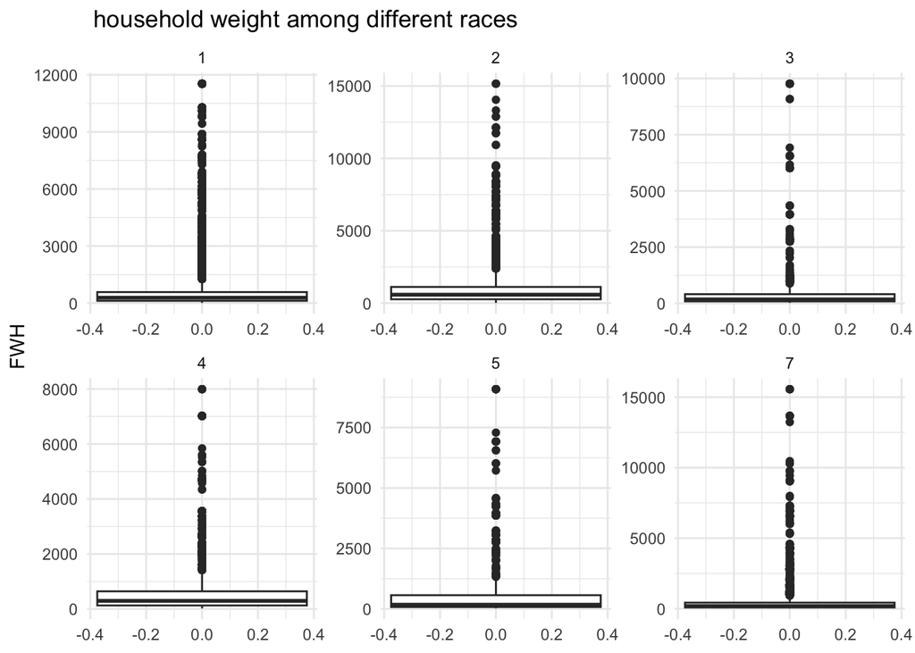

```r
screener_data%>%
  ggplot(aes(y= FWH))+
  geom_boxplot()+
  facet_wrap(vars(C_RACE_R), scales = "free")+
  theme_minimal()+
  labs(title = " household weight among different races")
```

```r
colnames(topical_data)
```

```
##   [1] "FIPSST"             "STRATUM"            "HHID"
##   [4] "FORMTYPE"           "TOTKIDS_R"          "TENURE"
##   [7] "HHLANGUAGE"         "SC_AGE_YEARS"       "SC_SEX"
##  [10] "K2Q35A_1_YEARS"     "BIRTH_MO"           "BIRTH_YR"
##  [13] "MOMAGE"             "K6Q41R_STILL"       "K6Q42R_NEVER"
##  [16] "K6Q43R_NEVER"       "K6Q13A"             "K6Q13B"
##  [19] "K6Q14A"             "K6Q14B"             "K4Q30_R_1"
##  [22] "K4Q30_R_2"          "K4Q30_R_3"          "DENTALSERV1"
##  [25] "DENTALSERV2"        "DENTALSERV3"        "DENTALSERV4"
##  [28] "DENTALSERV5"        "DENTALSERV6"        "DENTALSERV7"
##  [31] "K4Q28X01"           "K4Q28X02"           "K4Q28X03"
##  [34] "K4Q28X_EAR"         "K4Q28X04"           "K4Q28X05"
##  [37] "SESPLANYR"          "SESPLANMO"          "K4Q37"
##  [40] "SPCSERVMO"          "LIVEUSA_YR"         "LIVEUSA_MO"
##  [43] "K11Q43R"            "A1_AGE"             "A1_LIVEUSA"
```

[output cut: 139 more lines]

The variables that are most intriguing are ACE variables, which measured the adversity of children’s childhood experiences. There were studies conducted that showed that the severity of adversity experienced by children would significantly affect children’s long-term mental health as well as physical health.

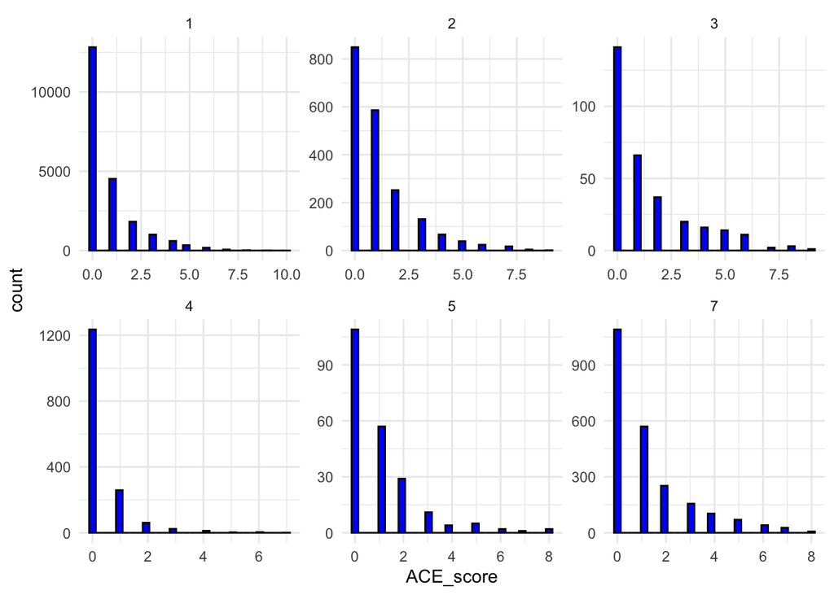

```r
topical_data %>%
  mutate(
    ACE3 = ifelse(ACE3 == 2, 0, 1),
    ACE4 = ifelse(ACE4 == 2, 0, 1),
    ACE5 = ifelse(ACE5 == 2, 0, 1),
    ACE6 = ifelse(ACE6 == 2, 0, 1),
    ACE7 = ifelse(ACE7 == 2, 0, 1),
    ACE8 = ifelse(ACE8 == 2, 0, 1),
    ACE9 = ifelse(ACE9 == 2, 0, 1),
    ACE10 = ifelse(ACE10 == 2, 0, 1),
    ACE11 = ifelse(ACE11 == 2, 0, 1),
    ACE12 = ifelse(ACE12 == 2, 0, 1)
  ) %>%
  mutate(
    ACE_score = ACE3 + ACE4 + ACE5 + ACE6 + ACE7 + ACE8 + ACE9 + ACE10 + ACE11 + ACE12
  ) %>%
  mutate(SC_RACER = as.character(SC_RACER)) %>%
  group_by(SC_RACE_R) %>%
  mutate(freq_ACE = sum(ACE_score)) %>%
  group_by(ACE_score) %>%
  mutate(freq_ACE_score = sum(ACE_score)) %>%
  mutate(prop_ACE = freq_ACE_score / freq_ACE) %>%
  ggplot(aes(x = ACE_score)) +
  geom_histogram(bins = 30, fill = "blue", color = "black", position = "identity") +
  facet_wrap(vars(SC_RACE_R), scales = "free") +
  theme_minimal()
```

```r
#
#   mutate(SC_RACE_R = as.character(SC_RACE_R)) %>%
#   group_by(SC_RACE_R, ACE_score) %>%
#   summarize(freq_ACE_score = n()) %>%
#   group_by(SC_RACE_R) %>%
#   summarize(
#     freq_ACE = sum(freq_ACE_score),
#     prop_ACE = freq_ACE_score / freq_ACE)%>%
#   ggplot(aes(x = prop_ACE))+
#   geom_freqpoly()+
#   facet_wrap(vars(SC_RACE_R))
```

```r
# # Create a bar chart to visualize the proportion of each ACE score within categories
# ggplot(ace_summary, aes(x = ACE_score, y = prop_ACE, fill = ACE_score)) +
#   geom_bar(stat = "identity") +
#   facet_grid(SC_RACE_R ~ .) +
#   labs(x = "ACE Score", y = "Proportion") +
#   scale_fill_discrete(name = "ACE Score") +
#   theme_minimal() +
#   ggtitle("Proportion of ACE Scores within Categories")
```